# Aprendizaje No Supervisado - Mineria de Datos

Leonardo Santella

Tuesday, April 05, 2016

## Introducción

En el área de ´Machine Learning´ (Aprendizaje automático en español), el aprendizaje No-Supervisado es la tarea encargada de encontrar estructuras desconocidas a priori, que se encuentran en un conjunto de datos. Se desconocen las estructuras intrínsecas del conjunto de datos debido a la ausencia de un atributo que de alguna manera guie (supervise) la formación de dichas estructuras.

´Clustering´ (agrupación en español) es una de las técnicas aplicadas en el aprendizaje No-Supervisado. En la actividad, se nos provee de una serie de conjuntos de datos y se requiere que apliquemos las técnicas ´clustering´ vistas en clases, de manera selectiva. Se debe argumentar cada decisión tomada en la realización de la actividad.

## Carga de librerias y conjuntos de datos

```r
#Biblioteca de graficacion 3D
library(rgl)
library(FactoMineR)
```

```r
library(scatterplot3d)
#Archivo de funciones definidas
source("funciones.R")

#Loading Datasets
a = read.csv("a.csv", header = F)
a_big = read.csv("a_big.csv", header = F)
good_luck = read.csv("good_luck.csv", header = F)
guess = read.csv("guess.csv", header = F)
h = read.csv("h.csv", header = F)
help = read.csv("help.csv", header = F)
moon = read.csv("moon.csv", header = F)
s = read.csv("s.csv", header = F)
```

# Análisis Exploratorio de los datos

```r
summary(a)
```

```
##        V1                V2                V3
##  Min.   :-19.612   Min.   :-20.006   Min.   :0
##  1st Qu.: -8.100   1st Qu.:-11.055   1st Qu.:0
##  Median :  7.869   Median : -8.121   Median :1
##  Mean   :  3.294   Mean   : -3.392   Mean   :1
##  3rd Qu.: 10.846   3rd Qu.:  7.943   3rd Qu.:2
##  Max.   : 21.015   Max.   : 20.680   Max.   :2
```

```r
summary(a_big)
```

```
##        V1                V2                V3
##  Min.   :-27.462   Min.   :-27.951   Min.   :0
##  1st Qu.: -7.305   1st Qu.:-11.275   1st Qu.:0
##  Median :  7.327   Median : -7.284   Median :1
##  Mean   :  3.345   Mean   : -3.329   Mean   :1
##  3rd Qu.: 11.277   3rd Qu.:  7.305   3rd Qu.:2
##  Max.   : 27.979   Max.   : 26.712   Max.   :2
```

```r
summary(good_luck)
```

```
##        V1                 V2                 V3
##  Min.   :-2.85300   Min.   :-3.07608   Min.   :-3.162396
##  1st Qu.:-0.66357   1st Qu.:-0.65641   1st Qu.:-0.707708
##  Median :-0.05781   Median : 0.03336   Median : 0.009084
##  Mean   :-0.01491   Mean   : 0.03993   Mean   : 0.009990
##  3rd Qu.: 0.60715   3rd Qu.: 0.74784   3rd Qu.: 0.683820
##  Max.   : 3.30694   Max.   : 4.16582   Max.   : 3.260145
##        V4                 V5                  V6
##  Min.   :-3.22759   Min.   :-3.204147   Min.   :-3.335482
##  1st Qu.:-0.76546   1st Qu.:-0.672720   1st Qu.:-0.677226
##  Median :-0.02199   Median :-0.006338   Median :-0.025197
##  Mean   :-0.05420   Mean   :-0.015037   Mean   : 0.000813
##  3rd Qu.: 0.60845   3rd Qu.: 0.659338   3rd Qu.: 0.678486
##  Max.   : 3.88554   Max.   : 3.191227   Max.   : 3.061311
##        V7                  V8                  V9
##  Min.   :-3.396008   Min.   :-3.073375   Min.   :-3.559169
##  1st Qu.:-0.663668   1st Qu.:-0.695388   1st Qu.:-0.685678
##  Median : 0.034641   Median : 0.016920   Median :-0.003808
##  Mean   :-0.002181   Mean   :-0.007488   Mean   :-0.006503
##  3rd Qu.: 0.627174   3rd Qu.: 0.647090   3rd Qu.: 0.664717
##  Max.   : 3.671617   Max.   : 3.737200   Max.   : 3.227338
##       V10                V11
##  Min.   :-3.05439   Min.   :0.000
##  1st Qu.:-0.70022   1st Qu.:0.000
##  Median :-0.04033   Median :0.000
##  Mean   :-0.01427   Mean   :0.487
##  3rd Qu.: 0.68201   3rd Qu.:1.000
##  Max.   : 2.96082   Max.   :1.000
```

```r
summary(guess)
```

```
##        V1                V2
##  Min.   :-38.575   Min.   :-34.207
##  1st Qu.:-10.144   1st Qu.: -8.089
##  Median :  5.529   Median :  7.426
##  Mean   :  6.903   Mean   :  8.853
##  3rd Qu.: 17.894   3rd Qu.: 21.857
##  Max.   : 67.537   Max.   : 68.029
```

```r
summary(h)
```

```
##        V1               V2                 V3                 V4
##  Min.   :-9.608   Min.   :-0.02557   Min.   :-11.3510   Min.   : 4.718
##  1st Qu.:-3.311   1st Qu.: 5.37268   1st Qu.: -4.7355   1st Qu.: 7.046
##  Median : 3.112   Median :10.84431   Median :  0.7600   Median : 9.249
##  Mean   : 1.957   Mean   :10.73390   Mean   :  0.6411   Mean   : 9.386
##  3rd Qu.: 6.199   3rd Qu.:16.33213   3rd Qu.:  6.6741   3rd Qu.:11.661
##  Max.   :12.777   Max.   :21.16627   Max.   : 14.2422   Max.   :14.135
```

```r
summary(help)
```

```
##        V1                V2                 V3                  V4
##  Min.   :-10.000   Min.   :-0.02557   Min.   :-19.99995   Min.   :-4.712
##  1st Qu.:  6.864   1st Qu.: 4.93492   1st Qu.:-10.21263   1st Qu.:-1.180
##  Median : 30.112   Median : 9.98509   Median :  0.09956   Median : 2.426
##  Mean   : 27.848   Mean   :10.07264   Mean   :  0.10830   Mean   : 3.141
##  3rd Qu.: 47.801   3rd Qu.:15.20300   3rd Qu.:  9.93020   3rd Qu.: 7.045
##  Max.   : 65.000   Max.   :21.16627   Max.   : 19.99975   Max.   :14.135
```

```r
summary(moon)
```

```
##        V1                 V2                V3
##  Min.   :-1.11299   Min.   :-0.5994   Min.   :0.0
##  1st Qu.:-0.03567   1st Qu.:-0.2145   1st Qu.:0.0
##  Median : 0.48495   Median : 0.2462   Median :0.5
##  Mean   : 0.49760   Mean   : 0.2498   Mean   :0.5
##  3rd Qu.: 1.03710   3rd Qu.: 0.7040   3rd Qu.:1.0
##  Max.   : 2.09638   Max.   : 1.1232   Max.   :1.0
```

```r
summary(s)
```

```
##        V1                 V2                 V3
##  Min.   :-1.00000   Min.   :0.000735   Min.   :-1.99998
##  1st Qu.:-0.75703   1st Qu.:0.510429   1st Qu.:-1.34367
##  Median :-0.09189   Median :1.038975   Median : 0.01552
##  Mean   :-0.04114   Mean   :1.022700   Mean   : 0.04017
##  3rd Qu.: 0.69542   3rd Qu.:1.556196   3rd Qu.: 1.40985
##  Max.   : 1.00000   Max.   :1.997053   Max.   : 1.99998
##        V4
##  Min.   :-4.70724
##  1st Qu.:-2.37869
##  Median :-0.17603
##  Mean   :-0.03844
##  3rd Qu.: 2.23613
##  Max.   : 4.71059
```

En la actividad, se indica que a excepción del set de datos guess.csv, la última columna es la clase. Se nos provee de una columna clase para poder evaluar los modelos de ´clustering´ a través de una matriz de confusión.

Por convención en esta actividad, la asignación de las clases y posteriormente, de los grupos, serán números enteros mayores que 0. En algunos datasets, la columna clase tiene valores reales y negativos.

Además, se nos indica que en algunos conjuntos de datos, debemos aplicar reglas para la elección de la clase, según un intervalo.

Los conjuntos de datos que se deben aplicar reglas para la asignación de una clase, son h, help y s. Para esto, graficaremos un histograma de frecuencia, y asignaremos intervalos equidistantes para la asignación de una clase.

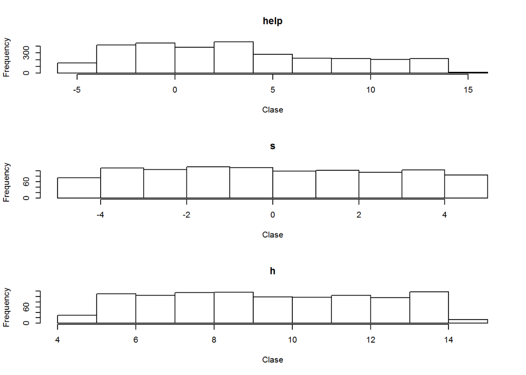

```r
# Datasets en las que se deben aplicar reglas para asignar clases
g1 = list(help, s, h)
names = c("help", "s", "h")
layout(1:3)
histograms = list()
clases = list()
j = 1
for ( i in g1 ){
  histograms[[j]] = hist( i$V4, main = names[j],xlab =  "Clase")
  clases[[j]] = asignarClase(histograms[[j]]$breaks, i$V4)
  j = j + 1
}
```

```r
# Las clases fueron asignadas de acuerdo a intervalos equidistantes
help$clase = clases[[1]]
s$clase = clases[[2]]
h$clase = clases[[3]]
```

La razón por la que se escogieron clases derivadas de intervalos con rangos iguales (equidistantes) es que al ver el histograma de frecuencia, podría inferirse que la columna de clase fue generada a través de una variable aleatoria con distribución uniforme. Por esa razón, la cantidad de elementos de cada clase debe ser parecida.

Las clases fueron asignadas desde 1 hasta el máximo entero de la secuencia generada por la cardinalidad de los cortes.

El resto de los conjuntos de datos que poseen una clase, están definidos desde el número 0. Esto puede traer confusiones al momento de evaluar el modelo de clustering.

```r
g2 = list(a, a_big, good_luck, moon)
a$clase = a$V3 +1
a_big$clase = a_big$V3 + 1
good_luck$clase = good_luck$V11 + 1
moon$clase = moon$V3 + 1
```

El único set de datos que no tiene una clase ya definida, es guess.csv. Luego, para determinar el número de conglomerados, se determinará el k, que acumule menos error, a fin de maximizar las distancias inter-cluster (como consecuencia, se minimizan las distancias intra-cluster).

```r
summary(help)
```

```
##        V1                V2                 V3                  V4
##  Min.   :-10.000   Min.   :-0.02557   Min.   :-19.99995   Min.   :-4.712
##  1st Qu.:  6.864   1st Qu.: 4.93492   1st Qu.:-10.21263   1st Qu.:-1.180
##  Median : 30.112   Median : 9.98509   Median :  0.09956   Median : 2.426
##  Mean   : 27.848   Mean   :10.07264   Mean   :  0.10830   Mean   : 3.141
##  3rd Qu.: 47.801   3rd Qu.:15.20300   3rd Qu.:  9.93020   3rd Qu.: 7.045
##  Max.   : 65.000   Max.   :21.16627   Max.   : 19.99975   Max.   :14.135
##      clase
##  Min.   : 1.000
##  1st Qu.: 3.000
##  Median : 5.000
##  Mean   : 5.061
##  3rd Qu.: 7.000
##  Max.   :11.000
```

Luego de asignar la clase correspondiente al conjunto de datos help, y posteriormente, realizar un grafico 3D interactivo a través de la biblioteca rgl, es notable que las clases no están bien asignadas. En el gráfico se puede ver que ambas letras S (ya que es una representación de las siglas SOS, en R^3) tienen las mismas clases.

Este problema esta sujeto a la interpretación del analista. En este caso, la forma en que se solucionará el problema, es asignando una clase a cada letra.

NOTA: Para poder visualizar lo realizado, es necesario correr la sección de código “Help New Class”, el archivo script.R.

```r
help$clase2 = 0
help[ 1:1000, ]$clase2 = 1
help[ 1001:2000, ]$clase2 = 2
help[ 2001:3000, ]$clase2 = 3
```

A continuación observaremos el dataset “guess.csv” y aplicaremos el codo de Jambú para escoger el número de clústeres que minimice la distancia intra-cluster, sin sobreajuste.

```r
summary(guess)
```

```
##        V1                V2
##  Min.   :-38.575   Min.   :-34.207
##  1st Qu.:-10.144   1st Qu.: -8.089
##  Median :  5.529   Median :  7.426
##  Mean   :  6.903   Mean   :  8.853
##  3rd Qu.: 17.894   3rd Qu.: 21.857
##  Max.   : 67.537   Max.   : 68.029
```

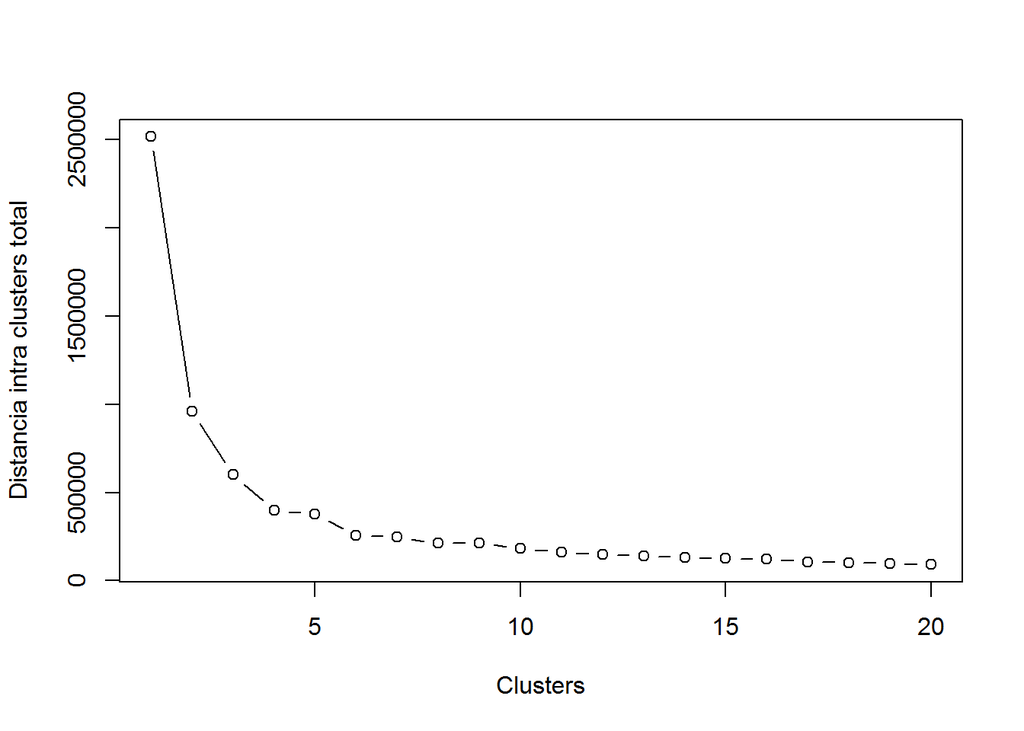

```r
ss = 1:20
for( i in 1:20){
  modelo = kmeans(x = guess, centers = i, iter.max = 20)
  ss[[i]] = modelo$tot.withinss
}
plot(1:20, ss, xlab = "Clusters", ylab = "Distancia intra clusters total",type = "b")
```

```r
kGuess = 5
```

```r
#Analizando Good_luck.csv
summary(good_luck)
```

```
##        V1                 V2                 V3
##  Min.   :-2.85300   Min.   :-3.07608   Min.   :-3.162396
##  1st Qu.:-0.66357   1st Qu.:-0.65641   1st Qu.:-0.707708
##  Median :-0.05781   Median : 0.03336   Median : 0.009084
##  Mean   :-0.01491   Mean   : 0.03993   Mean   : 0.009990
##  3rd Qu.: 0.60715   3rd Qu.: 0.74784   3rd Qu.: 0.683820
##  Max.   : 3.30694   Max.   : 4.16582   Max.   : 3.260145
##        V4                 V5                  V6
##  Min.   :-3.22759   Min.   :-3.204147   Min.   :-3.335482
##  1st Qu.:-0.76546   1st Qu.:-0.672720   1st Qu.:-0.677226
##  Median :-0.02199   Median :-0.006338   Median :-0.025197
##  Mean   :-0.05420   Mean   :-0.015037   Mean   : 0.000813
##  3rd Qu.: 0.60845   3rd Qu.: 0.659338   3rd Qu.: 0.678486
##  Max.   : 3.88554   Max.   : 3.191227   Max.   : 3.061311
##        V7                  V8                  V9
##  Min.   :-3.396008   Min.   :-3.073375   Min.   :-3.559169
##  1st Qu.:-0.663668   1st Qu.:-0.695388   1st Qu.:-0.685678
##  Median : 0.034641   Median : 0.016920   Median :-0.003808
##  Mean   :-0.002181   Mean   :-0.007488   Mean   :-0.006503
##  3rd Qu.: 0.627174   3rd Qu.: 0.647090   3rd Qu.: 0.664717
##  Max.   : 3.671617   Max.   : 3.737200   Max.   : 3.227338
##       V10                V11            clase
##  Min.   :-3.05439   Min.   :0.000   Min.   :1.000
##  1st Qu.:-0.70022   1st Qu.:0.000   1st Qu.:1.000
##  Median :-0.04033   Median :0.000   Median :1.000
##  Mean   :-0.01427   Mean   :0.487   Mean   :1.487
##  3rd Qu.: 0.68201   3rd Qu.:1.000   3rd Qu.:2.000
##  Max.   : 2.96082   Max.   :1.000   Max.   :2.000
```

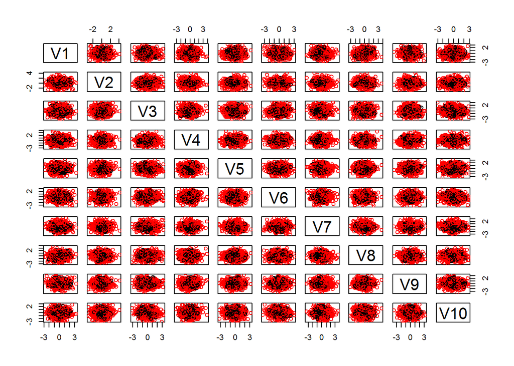

```r
pairs(good_luck[,-c(11,12)], col=good_luck$clase)
```

```r
pca = PCA(good_luck[,-c(11,12)])
```

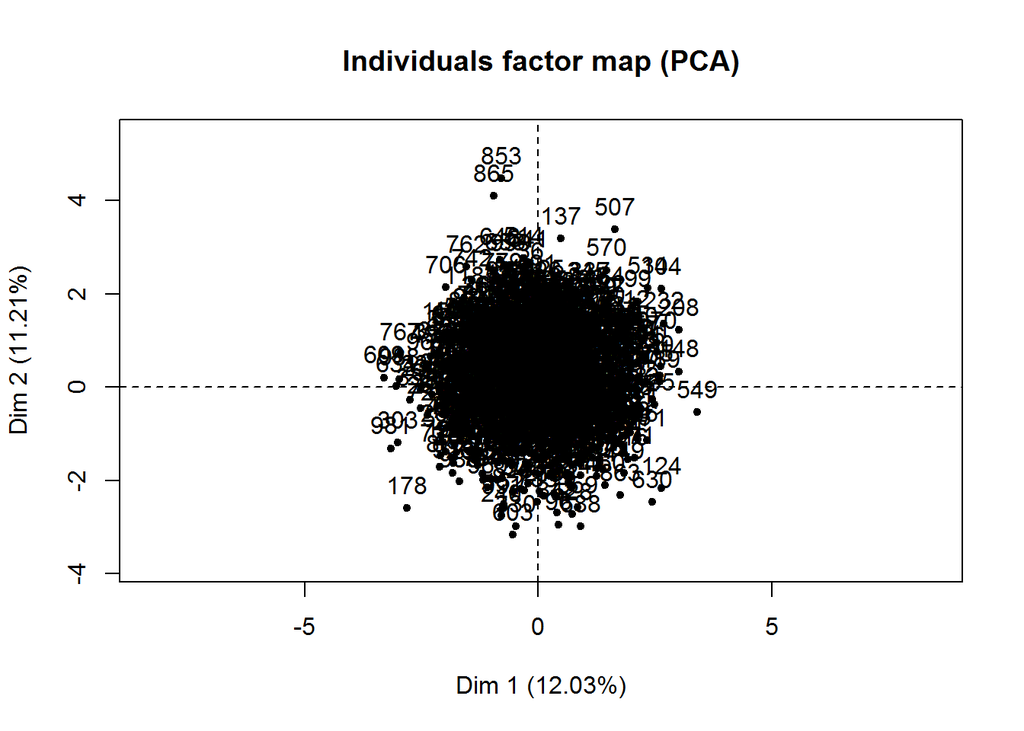

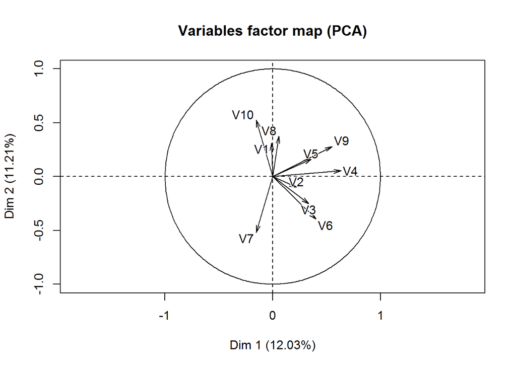

```r
pca$eig
```

```
##         eigenvalue percentage of variance
## comp 1   1.2025456              12.025456
## comp 2   1.1210352              11.210352
## comp 3   1.0529327              10.529327
## comp 4   1.0409954              10.409954
## comp 5   1.0195327              10.195327
## comp 6   0.9865676               9.865676
## comp 7   0.9507652               9.507652
## comp 8   0.9463918               9.463918
## comp 9   0.8782735               8.782735
## comp 10  0.8009603               8.009603
##         cumulative percentage of variance
## comp 1                           12.02546
## comp 2                           23.23581
## comp 3                           33.76514
## comp 4                           44.17509
## comp 5                           54.37042
## comp 6                           64.23609
## comp 7                           73.74374
## comp 8                           83.20766
## comp 9                           91.99040
## comp 10                         100.00000
```

Al realizar el gráfico 2 a 2 de las variables del set de datos, y además, aplicando un análisis de componentes principales, nos podemos dar cuenta, que los datos parecen no ser separables. Por lo tanto, no existe alguna manera de detectar con una precisión aceptable, los elementos de una clase o de otra.

Sin embargo, aplicaremos un modelo de “clustering” para dar soporte de lo anterior.

NOTA: Para observar el análisis exploratorio de los otros conjuntos de datos, correr la sección de código correspondiente al análisis exploratorio de cada uno.

# Definición de Modelos

## Dataset a.csv

En este conjunto de datos, podemos observar que solo posee 2 dimensiones (2 features) y por lo tanto podemos graficarlo en un plano.

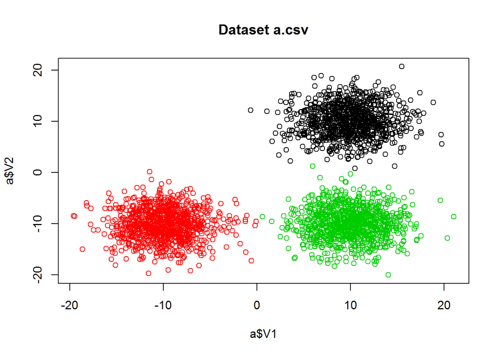

```r
plot(a$V1, a$V2, col=a$clase, main="Dataset a.csv")
```

Como podemos observar, los puntos están definidos 3 nubes de puntos, que tienen aproximadamente una forma circular.

Debido a la forma de las nubes de puntos, podemos decir que tanto la técnica de clusterización K-Medias como Clusterización Jerárquica tomando la máxima distancia (“complete”), generaran buenos modelos. Sin embargo, aplicaremos K-Medias, ya que nos beneficiaremos de los centroides generados por el algoritmo, para establecer un punto de partida en el algoritmo que aplicaremos en el dataset a_big.csv, ya que este posee una distribución similar, pero tiene una dimensionalidad 100 veces mayor.

NOTA: El algoritmo utilizado se encuentra definido en el archivo funciones.R

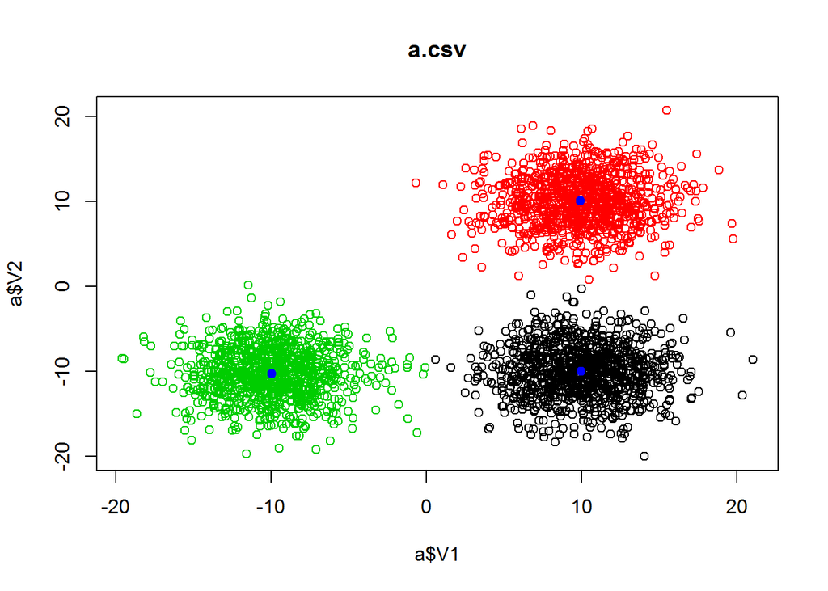

```r
a.model = kMeans(a[,c(1,2)], centers=3, max.iter=50)
plot(a$V1, a$V2, col=a.model[[2]], main="a.csv")
points(a.model[[1]], pch=19, col=4)
```

## Dataset a_big.csv

Este conjunto de datos posee una distribución similar al anterior. Su dimensionalidad es 100 veces mayor en cuanto a las filas. Además, su nombre es un hint.

Para la definición de un modelo de clusterización para este dataset, utilizaremos el algoritmo de K-Medias, pero iniciando con los centroides obtenidos en el modelo anterior.

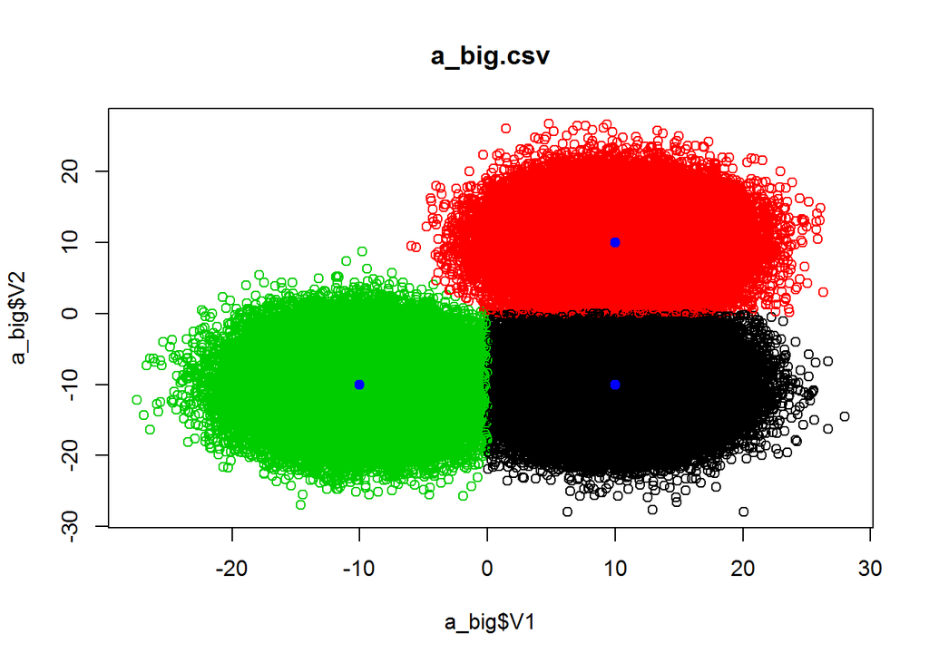

```r
a_big.model = kMeans(a_big[,c(1,2)], centers=3, max.iter=50, centros=a.model[[1]])
plot(a_big$V1, a_big$V2, col=a_big.model[[2]], main="a_big.csv")
points(a_big.model[[1]], pch=19, col=4)
```

## Dataset good_luck.csv

Anteriormente, en el análisis exploratorio, es notable que el set de datos posee más de tres dimensiones. Al observar los gráficos de dispersión 2 a 2, se puede llegar a la conclusión que ninguna técnica de clusterización vista en clase podrá generar un modelo aceptable. Esto se debe a que al parecer, los puntos que pertenecen a cada clase, no son separables, quizás en alguna dimensión superior se puede lograr un modelo aceptable, sin embargo no sabemos cómo lidie dicho modelo el problema de sobreajuste.

Aplicaremos un modelo de K-Medias, para observar los resultados y analizar el rendimiento luego, con el fin de dar soporte a lo anterior.

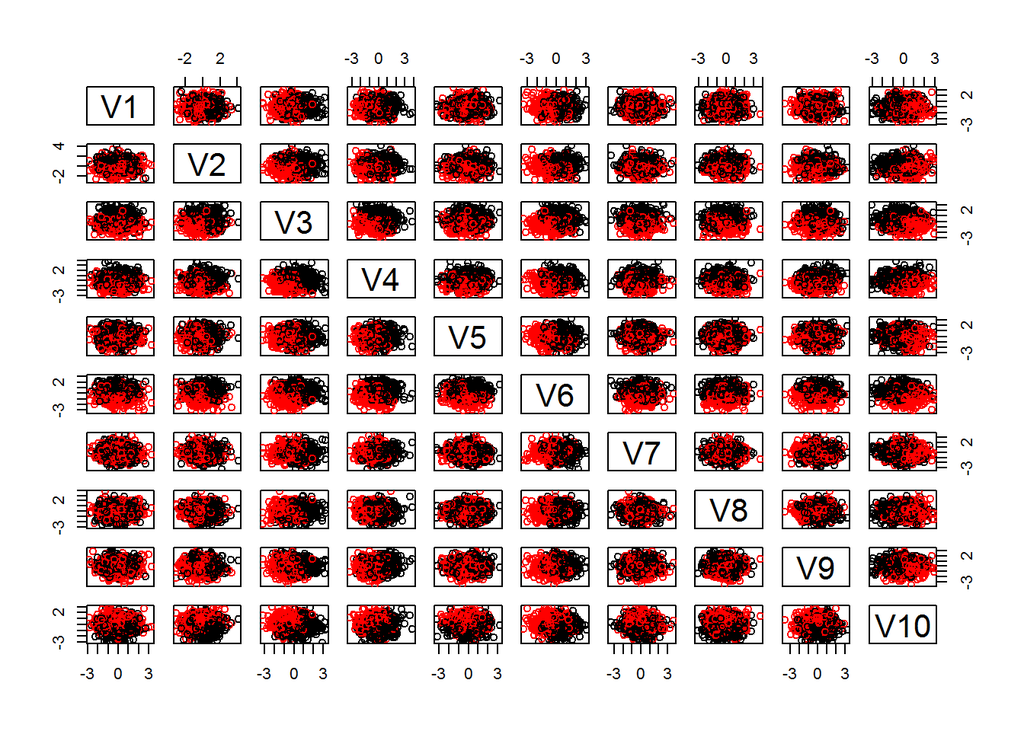

```r
good_luck.model = kmeans(good_luck[,-c(11,12)], centers=2, iter.max=20)
plot(good_luck[,-c(11,12)], col=good_luck.model$cluster)
```

En el gráfico podemos ver como los puntos que pertenecen a un clúster o a otro, están sobrepuestos, por lo tanto, la precisión no será aceptable.

## Dataset guess.csv

Para este set de datos, no podremos evaluar su rendimiento ya que no tenemos una columna clase con la cual comparar, a través de una matriz de confusión.

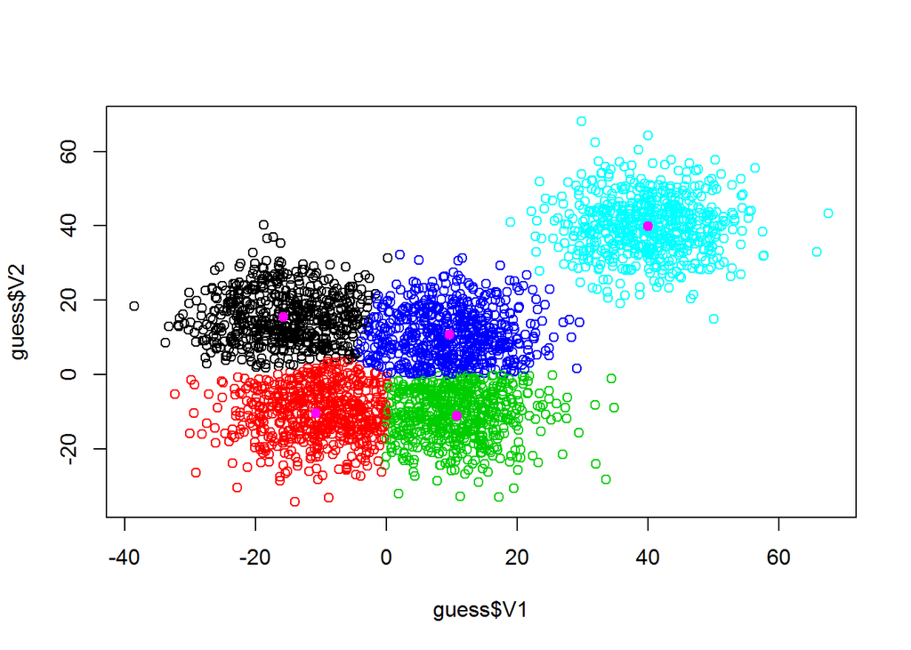

```r
guess.model = kmeans(guess, centers = 5, iter.max=30)
guess$cluster = guess.model$cluster
plot(guess$V1, guess$V2, col=guess$cluster)
points(guess.model$centers, pch=19, col=6, main="Dataset guess.csv")
```

## Dataset h.csv

Este conjunto de datos posee 3 dimensiones, al graficarlo (en script.R), se observa que posee una forma de espiral, y en ese espiral, están repartidos los clústeres en una forma rectangular. Para este set de datos, utilizaremos el algoritmo de clusterización jerárquica, sin embargo, los clústeres poseen formas arbitrarias que hacen que ningún modelo visto en clase tenga una precisión aceptable.

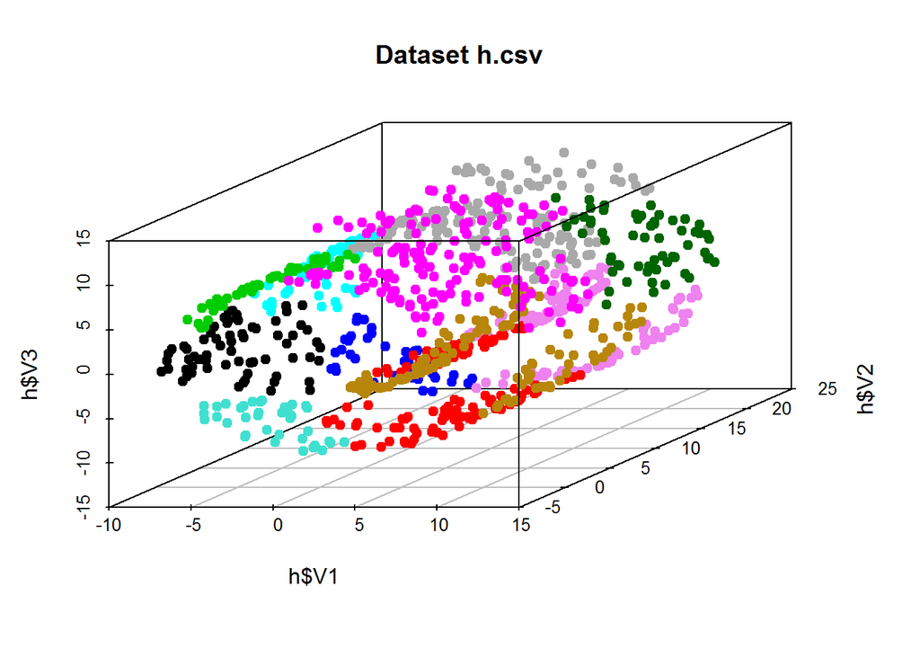

```r
h.distance.matrix = dist(as.matrix(h[,c(1,2,3)]))
h.model = hclust(h.distance.matrix, method="complete")
h.corte = cutree(h.model, 11)
scatterplot3d(h$V1, h$V2, h$V3, color=h.corte, pch=19, main="Dataset h.csv")
```

Este dataset, es similar al anterior (h.csv) en cuanto dimensionalidad, pero se diferencian en la figura formada. Esta figura, es una figura arbitraria (tiene forma de “s”), de manera que es posible que no se genere un modelo con la precisión requerida.

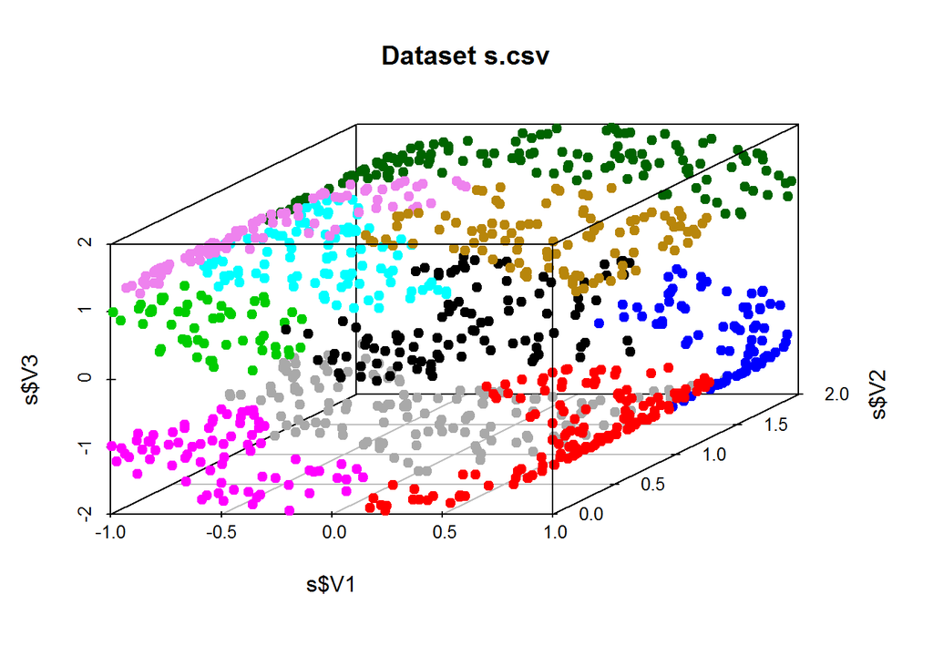

```r
s.distance.matrix = dist(as.matrix(s[,c(1,2,3)]))
s.model = hclust(s.distance.matrix, method="complete")
s.corte = cutree(s.model, 10)
scatterplot3d(s$V1, s$V2, s$V3, color=s.corte, pch=19, main="Dataset s.csv")
```

## Dataset help.csv

El set de datos help.csv, es una combinación de los 2 anteriores. Está compuesto por la unión de 2 set de datos s (s.csv) y un h (h.csv) trasladados y colocados en un mismo espacio 3D.

Al ver el gráfico, es evidente que cada letra puede ser tomada como un clúster, y luego, aplicar otro modelo de clusterización, dependiendo si el punto pertenece a una s o a la h.

Se utilizará el algoritmo de clusterización jerárquica con el método “single”, ya que cada letra (clúster en forma de letra), podría ser perfectamente cubierta por la forma de un rectángulo, que es una de las situaciones en donde el método se comporta de una manera adecuada.

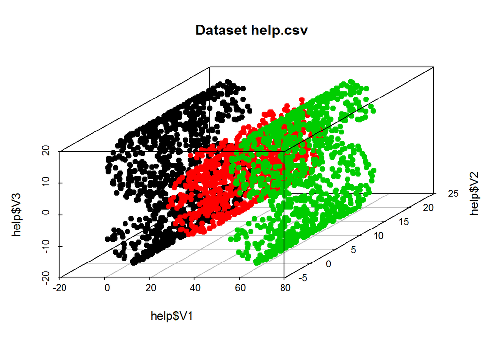

```r
help.distance.matrix = dist(as.matrix(help[,c(1,2,3)]))
help.model = hclust(help.distance.matrix, method="single")
help.corte = cutree(help.model,3)
scatterplot3d(help$V1, help$V2, help$V3, color=help.corte, pch=19, main="Dataset help.csv")
```

## Dataset moon.csv

Este conjunto de datos, está formado por puntos en 2 dimensiones. Los puntos que pertenecen a diferentes clases se agrupan en clústeres que no tienen forma esférica, por lo que la técnica de clusterización jerárquica con el método “single” deberá mostrar resultados adecuados.

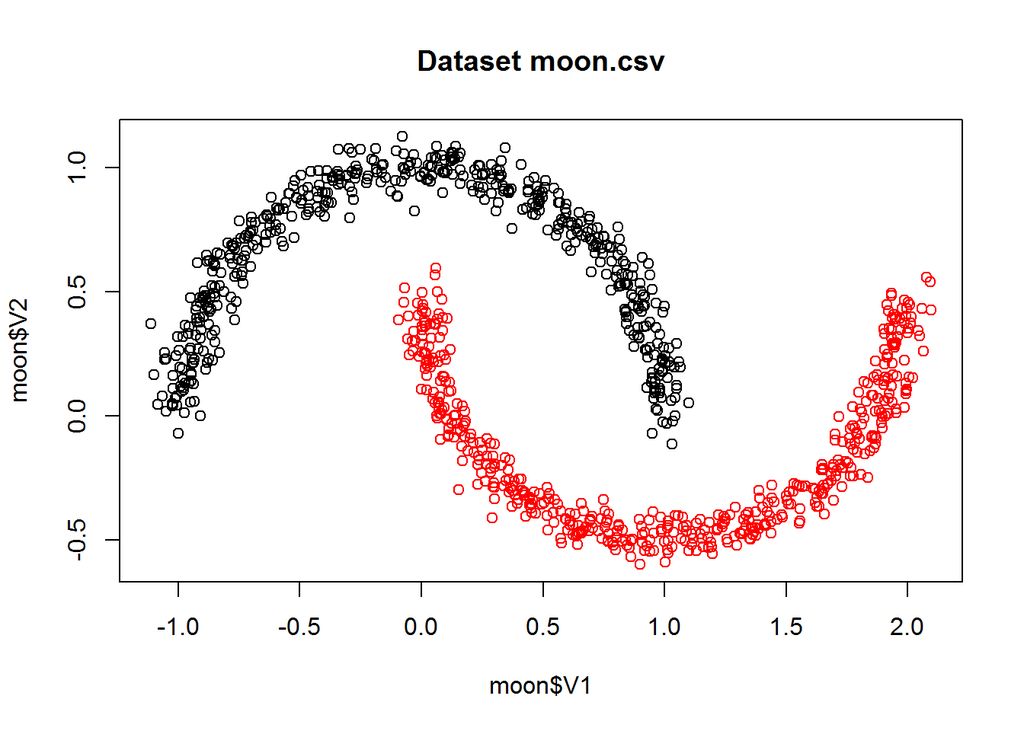

```r
moon.distance.matrix = dist(as.matrix(moon[,c(1,2)]))
moon.model = hclust(moon.distance.matrix, method="single")
moon.corte = cutree(moon.model, 2)
plot(moon$V1, moon$V2, col=moon.corte, main="Dataset moon.csv")
```

# Evaluación de modelos

La evaluación de los modelos, será basada en la matriz de confusión generada por la columna de clase y el número de clúster asignado por el modelo de clusterización a cada observación. Si la matriz es 2x2, se asumirá como clase (clúster en este caso) objetivo a “1”, y se realizará el cálculo de la sensibilidad, precisión, y F1 Score.

## K-Medias - a.csv

```r
a.conf = table(a$clase, a.model[[2]], dnn=c("Clase", "Cluster"))
a.conf = fix.conf.table(a.conf)
a.conf
```

```
##      Cluster
## Clase    1    2    3
##     1 1000    0    0
##     2    0 1000    0
##     3    1    0  999
```

```r
eval.conf.matrix(a.conf)
```

```
## La exactitud del modelo es:  0.9996667
## tps:  2999
## fs:  1
```

## K-Medias - a_big.csv

```r
a_big.conf = table(a_big$clase, a_big.model[[2]], dnn=c("Clase", "Cluster"))
a_big.conf = fix.conf.table(a_big.conf)
a_big.conf
```

```
##      Cluster
## Clase     1     2     3
##     1 99405    11   584
##     2    14 99401   585
##     3   666   589 98745
```

```r
eval.conf.matrix(a_big.conf)
```

```
## La exactitud del modelo es:  0.9918367
## tps:  297551
## fs:  2449
```

## K-Medias - good_luck.csv

```r
good_luck.conf = table(good_luck$clase, good_luck.model$cluster, dnn=c("Clase", "Cluster"))
good_luck.conf = fix.conf.table(good_luck.conf)
good_luck.conf
```

```
##      Cluster
## Clase   1   2
##     1 273 240
##     2 229 258
```

```r
eval.conf.matrix(good_luck.conf)
```

```
## Precision:  0.5438247
## Sensibilidad:  0.5321637
## F1 Score:  0.537931
```

## Clusterización Jerarquica Complete Link - h.csv

```r
h.conf = table(h$clase, h.corte, dnn=c("Clase", "Cluster"))
h.conf = fix.conf.table(h.conf)
h.conf
```

```
##      Cluster
## Clase  1  2  3  4  5  6  7  8  9 10 11
##    1   0  8  0  0  0  0  0 14  8  0  0
##    2   0 42  0  0  0  0  0 33 35  0  0
##    3   0 26  0 22  0  0  0  0 43  0 13
##    4   0  0  0 54  2  0  0  0  1  0 58
##    5  31  0  0 38 42  0  0  0  0  0  5
##    6  34  0  0  0  8 53  3  0  0  0  0
##    7   0  0  0  0  0 12 39  9  0 37  0
##    8   0 34  0  0  0  0  0 61  8  1  0
##    9   0 16 32  0  0  0  0  0 35  0 12
##    10  0  0 30 25  0  0  0  0  0  0 63
##    11  0  0  0  6  0  0  0  0  0  0  7
```

```r
eval.conf.matrix(h.conf)
```

```
## La exactitud del modelo es:  0.333
## tps:  333
## fs:  667
```

## Clusterización Jerarquica Complete Link - s.csv

```r
s.conf = table(s$clase, s.corte, dnn=c("Clase", "Cluster"))
s.conf = fix.conf.table(s.conf)
s.conf
```

```
##      Cluster
## Clase  1  2  3  4  5  6  7  8  9 10
##    1  52 23  0  0  0  0  0  0  0  0
##    2  46 53 11  0  0  0  0  0  0  0
##    3   0 46 59  0  0  0  0  0  0  0
##    4   0 12 21  0 63  0 19  0  0  0
##    5   0  0  0  0 40 38 34  0  0  0
##    6   0  0  0 23  0 60  0 16  0  0
##    7   0  0  0 40  0  0  0 62  0  0
##    8   0  0  0 16  0  0  0 49 30  0
##    9   0  0  0  0  0  0  0  3 71 29
##    10  0  0  0  0  0  0  0  0 38 46
```

```r
eval.conf.matrix(s.conf)
```

```
## La exactitud del modelo es:  0.43
## tps:  430
## fs:  570
```

## Clusterización Jerarquica Single Link - help.csv

```r
help.conf = table(help$clase2, help.corte, dnn=c("Clase", "Cluster"))
help.conf = fix.conf.table(help.conf)
help.conf
```

```
##      Cluster
## Clase    1    2    3
##     1 1000    0    0
##     2    0 1000    0
##     3    0    0 1000
```

```r
eval.conf.matrix(help.conf)
```

```
## La exactitud del modelo es:  1
## tps:  3000
## fs:  0
```

## Clusterización Jerarquica Single Link - moon.csv

```r
moon.conf = table(moon$clase, moon.corte, dnn=c("Clase", "Cluster"))
moon.conf = fix.conf.table(moon.conf)
moon.conf
```

```
##      Cluster
## Clase   1   2
##     1 500   0
##     2   0 500
```

```r
eval.conf.matrix(moon.conf)
```

```
## Precision:  1
## Sensibilidad:  1
## F1 Score:  1
```

# Conclusión

En los modelos obtenidos luego de aplicar K-Medias en los dataset a.csv y a_big.csv, se obtuvieron muy buenos resultados. Esto se debe a que los clústeres tienen una forma esférica. Es importante resaltar que una esfera en 2 dimensiones, es una circunferencia (o un círculo).

Los resultados obtenidos luego de aplicar K-Medias al dataset good_luck.csv, nos damos cuenta que el modelo acertó el 50% de las veces, sin embargo, esto es equivalente a lanzar una moneda justa y clasificar en base al resultado. Este resultado es coherente, ya que los puntos que pertenecen a las 2 clases proporcionadas, están mezclados entre sí, de manera que dificulta la toma de decisión a la hora de asignar el clúster correcto.

El dataset guess.csv no fue evaluado, ya que no teníamos una variable para contrastar los resultados.

El modelo generado para el dataset help.csv, se comporta de manera perfecta, al igual que el modelo generado para el set de datos moon.csv. Ambos conjuntos de datos, presentan agrupaciones con formas a las que el algoritmo de clusterización jerárquica se adapta perfectamente.

# Consideraciones

Las funciones utilizadas y que no están expuestas explicitamente en este informe, se encuentran definidas en el archivo funciones.R.